# MATH-509: Lab 3

**Daniel Carter**

## Getting Started

Follow the instructions below to copy this notebook and to perform some initial setup.

1. Copy this notebook by selecting `File > Save a copy in Drive`.
2. A new window should open for the copied notebook. Move the new notebook to your course folder in Google Drive by selecting `File > Move` and then selecting the desired folder.
3. Update the name of the notebook by removing "Copy of" and replacing "Username" with your actual username.
4. Update the first cell in the notebook by replacing "Student Name" with your actual name.
5. Mount your Google Drive by running the cell below and accepting the prompts you are presented with.

```python
from google.colab import drive
drive.mount('/content/drive')
```

## Import Statements

Run the cell below to import the NumPy package. **No other import packages are to be used in this assignment.**

```python
import numpy as np
```

## Loops and NumPy

The tasks described in the problems within this notebook are intended to be performed using tools from NumPy rather than with loops. The only loop that should appear in this lab is in Problem 3, where the structure of the loop is already provided for you.

# Problem 1 - Inverse of a Product

### Problem Background

In this problem, we will explore a property of matrix algebra. In particular, we will discuss how the inverse and matrix multiplication operations interact. It can be shown the following equation holds true for any two invertible matrices $A$ and $B$:

$$\large \left(AB \right)^{-1} = B^{-1} A^{-1} $$

This algebraic rule could be read as "the inverse of a product is equal to the product of the inverses." However, as it typically the case with matrices, the order of the matrices in the product matters! We can easily find examples where $ B^{-1} A^{-1} \neq A^{-1} B^{-1} $, and so we are not generally able to swap the order of the product on the right side of the equation above.

We will consider an example to demonstrates these facts.

### Instructions

Use the cell below to perform the following tasks:

1. Create lists-of-lists or arrays to represent the following two matrices:

$$ A = \begin{bmatrix} 5 & 3\\ 3 & 2 \\ \end{bmatrix} \quad\quad\quad B = \begin{bmatrix} 3 & 8\\ 2 & 5 \\ \end{bmatrix} $$

1. Calculate each of the following matrices, storing the results in Python variables.

$$ A^{-1} \quad\quad B^{-1} \quad\quad A B \quad\quad (A B)^{-1} \quad\quad B^{-1} A^{-1} \quad\quad A^{-1} B^{-1} $$

```python
A = np.array([[5,3],
             [3,2]])
B = np.array([[3,8],
              [2,5]])

A_inv = np.linalg.inv(A)
B_inv = np.linalg.inv(B)
AB = np.matmul(A, B)
AB_inv = np.linalg.inv(AB)
BinvXAinv = np.matmul(B_inv, A_inv)
AinvXBinv = np.matmul(A_inv, B_inv)
```

Additional Instructions

The cell below is intended to print the following matrices:

$$ (A B)^{-1} \quad\quad B^{-1} A^{-1} \quad\quad A^{-1} B^{-1} $$

Replace the blanks in the cell with the names of the variables you created above, as appropriate. Then run the cell. The ouptut of the cell should confirm that both of the following statements are true:

$$\large \left(AB \right)^{-1} = B^{-1} A^{-1} $$$$\large \left(AB \right)^{-1} \neq A^{-1} B^{-1} $$

```python
print('AB inverse:\n--------------')
print(AB_inv)
print()

print('A_inv * B_inv\n--------------')
print(AinvXBinv)
print()

print('B_inv * A_inv:\n--------------')
print(BinvXAinv)
print()
```

```
AB inverse:
--------------
[[-34.  55.]
 [ 13. -21.]]

A_inv * B_inv
--------------
[[-16.  25.]
 [ 25. -39.]]

B_inv * A_inv:
--------------
[[-34.  55.]
 [ 13. -21.]]
```

# Problem 2 - Magnitude or Length of Vectors

### Problem Background

The **length** or **magnitude** of a vector is a number that, in some way, represents the size of the vector. There is a nice geometric way of thinking about the length of a vector, which you can (optionally) learn more about in the following video from the rootmath YouTube channel: [Length of a 3D Vector](https://www.youtube.com/watch?v=MoHMw0ZO7bU)

We will now discuss how to calculate the magnitude of a vector. Consider the following N-dimensional vector:

$$\large v = [v_1, v_2, v_3, ..., v_N] $$

The length or magnitude the vector $v$ is denoted by $\|v\|$ and is calculated using the formula shown below:

$$\large \|v\| = \sqrt{\sum_{i=1}^N v_i^2} $$

### Instructions

In the cell below, create a function named `magnitude()` with a single parameter named `v`. This parameter is intended to be a list or 1D array representing a vector.

The first line of your function should convert `v` to an array using the following code: `v = np.array(v)`

Your function should then calculate and return the magnitude of `v`.

### Guidance

The steps in the process of calculating $\|v\|$ can be described as follows:

1. Square all of the elements of $v$.
2. Calculate the sum of the square of the elements of $v$.
3. Take the square root of the sum of the squares.

You can perform these steps with a single line of code or multiple lines of code.

```python
def magintude(v):
  v = np.array(v)
  mag = np.sqrt(np.sum(v**2))
  return mag
```

Additional Instructions

Use the cell below to complete the following steps:

1. Create lists or arrays to represent the following three vectors:

$$ v_1 = [3,~ -4] \quad\quad v_2 = [6,~ -7,~ 4] \quad\quad v_3 = [-2,~ 5,~ 1,~ 3] $$

1. Use the `magnitude()` function to calculate the magnitude of each of the three vectors, storing the results in variables.
2. Print the magnitudes of the three vectors.

```python
v1 = np.array([3,-4])
v2 = np.array([6,-7,4])
v3 = np.array([-2,5,1,3])

mag1 = magintude(v1)
mag2 = magintude(v2)
mag3 = magintude(v3)

print(f'Magintude 1: {mag1}')
print(f'Magintude 2: {mag2}')
print(f'Magintude 3: {mag3}')
```

```
Magintude 1: 5.0
Magintude 2: 10.04987562112089
Magintude 3: 6.244997998398398
```

Additional Instructions

The `linalg` module in NumPy has a `norm()` function that performs the same calculation as the `magnitude()` function that we have created. You can verify this by replacing the blanks in the cell below with the names of the three vectors you created.

```python
print(np.linalg.norm(mag1))
print(np.linalg.norm(mag2))
print(np.linalg.norm(mag3))
```

```
5.0
10.04987562112089
6.244997998398398
```

# Problem 3 - L-Norms

### Problem Background

The magnitude of a vector that was discussed in Problem 2 is a special case of something called an **L-norm**. Suppose that a vector $v$ is given as follows:

$$\large v = [v_1, v_2, v_3, ..., v_N] $$

Let $L$ be a positive integer. The **L-norm** of the vector $v$ is denoted by $\|v\|_L$ and is calculated using the formula shown below:

$$\large \|v\|_L = \left(\sum_{i=1}^N |v_i|^L \right) ^{1/L} $$

The magnitude of a vector is a special case of the L-norm where $L=2$.

Versions of the L-norm (especially the 1-norm and 2-norm) are used in machine learning to apply **regularization techniques** that can be used to prevent models from over-fitting. You will likely encounter regularization in courses relating to machine learning and deep learning.

### Instructions

In the cell below, create a function named `lnorm()` with two parameters, `v` and `L`. The parameter `v` is intended to be a list or 1D array that represents a vector. The parameter `L` is intended to be a positive integer.

The first line of your function should convert `v` to an array using the following code: `v = np.array(v)`

Your function should then calculate and return the L-norm of `v`.

### Guidance

The steps in the process of calculating $\|v\|_L$ can be described as follows:

1. Find the absolute value of the elements of $v$ using `np.abs()`.
2. Raise each element of the array from step 1 to the power `L`.
3. Calculate the sum of the array created in step 2.
4. Raise the sum from step 3 to the power `1/L`.

You can perform these steps with a single line of code or multiple lines of code. Pay careful attention to the order of operations and to your use of parentheses for grouping calculatations.

```python
def lnorm(v, L):
  v = np.array(v)
  lnorm = (np.sum(np.abs(v**L)))**(1/L)
  return lnorm
```

Additional Instructions

Replace the blanks in the cell below with the names of the vectors you created in Problem 2. Then run the cell to calculate the L-norm of each of the vectors for $L=1, 2, 3, 4, 5$.

```python
for v in [v1, v2, v3]:
    for i in range(1, 6):
        norm_value = lnorm(v, L=i)
        print(f'The L{i}-norm of {v} is {norm_value}')
    print()
```

```
The L1-norm of [ 3 -4] is 7.0
The L2-norm of [ 3 -4] is 5.0
The L3-norm of [ 3 -4] is 4.497941445275415
The L4-norm of [ 3 -4] is 4.284572294953817
The L5-norm of [ 3 -4] is 4.174027662897746

The L1-norm of [ 6 -7  4] is 17.0
The L2-norm of [ 6 -7  4] is 10.04987562112089
The L3-norm of [ 6 -7  4] is 8.540750116473752
The L4-norm of [ 6 -7  4] is 7.929242563982552
The L5-norm of [ 6 -7  4] is 7.615032133623672

The L1-norm of [-2  5  1  3] is 11.0
The L2-norm of [-2  5  1  3] is 6.244997998398398
The L3-norm of [-2  5  1  3] is 5.4401218254147965
The L4-norm of [-2  5  1  3] is 5.185427592735
The L5-norm of [-2  5  1  3] is 5.085355593774905
```

The `np.linalg.norm()` function mentioned in Problem 2 can be used to calculate L-norms. This function has an optional `order` parameter that plays the same role as the `L` parameter in your `lnorm()` function. If you wish, you can create a cell below to test whether your `lnorm()` function gives the same results as `np.linalg.norm()`. If you do so, please delete the new cell before submitting your notebook.

# Problem 4 - Cosine Similarity

### Problem Background

The **cosine similarity** is a measure often used to indicate the similarity between two vectors. The cosine similarity for two vectors $x$ and $y$ is sometimes denoted as $S_C(x,y)$ and is calculated as shown below.

$$ S_C(x, y) = \frac{x \cdot y}{ \|x\| \cdot \|y\| }$$

Geometrically speaking, the cosine similarity is equal to the cosine of the angle between the two vectors, and thus measures the degree to which the two vectors point in the same direction. It is used in machine learning and artificial intelligence to compare objects represented as vectors. Its usage is especially common in the field of Natural Language Processing.

### Instructions

In the cell below, create a function named `cosine_sim()` with two parameters, `x` and `y`. Both parameters are inteded to be lists or 1D arrays representing vectors. Your function should calculate and return the cosine similarity of the two vectors.

### Guidance

Note that the numerator involves calculating a dot product. This can be accomplished using `np.dot()`. The denominator is equal to the product of the magnitudes of `x` and `y`. You can use your own `magnitude()` function from Problem 2 or the `np.linalg.norm()` function to calculate these magnitudes.

```python
def cosine_sim(x, y):
  num = np.dot(x, y)
  den = magintude(x) * magintude(y)
  cos_sim = num/den
  return cos_sim
```

Additional Instructions

Use the cell below to complete the following steps:

1. Create lists or arrays to represent the following three vectors:

$$ v_1 = [4,~ 1,~ 3,] \quad\quad v_2 = [5,~ 6,~ 4] \quad\quad v_3 = [2,~ 1,~ -3] $$

1. Use the `cosine_sim()` function to calculate the cosine similarity of each of the three possible pairs of vectors (`v1`/`v2`, `v1`/`v3`, and `v2`/`v3`).
2. Print the cosine similarity of each pair of vectors.

```python
v1 = np.array([4,1,3])
v2 = np.array([5,6,4])
v3 = np.array([2,1,-3])

v1v2 = cosine_sim(v1,v2)
v1v3 = cosine_sim(v1,v3)
v2v3 = cosine_sim(v2,v3)

print(f'Cosine Similarity for v1 and v2: {v1v2}')
print(f'Cosine Similarity for v1 and v3: {v1v3}')
print(f'Cosine Similarity for v2 and v3: {v2v3}')
```

```
Cosine Similarity for v1 and v2: 0.849281296908581
Cosine Similarity for v1 and v3: 0.0
Cosine Similarity for v2 and v3: 0.12182898077463453
```

# Problem 5 - Eigenvalues of an Inverse Matrix

### Problem Background

It can be shown that the eigenvalues of the inverse of a matrix $A$ are inverses of the eigenvalues of $A$ itself. Let's state this more formally. Suppose that $A$ is an invertible matrix and that $\lambda$ is an eigenvalue of $A$. Then $1/\lambda$ will be an eigenvalue of $A^{-1}$. We will demonstrate that fact in this problem.

### Instructions

Create a list-of-lists or an array to represent the following matrix:

$$ A = \begin{bmatrix} 8 & 3 & 0\\ -6 & 1 & 2 \\ 6 & 3 & 2\\ \end{bmatrix} $$

Use the `np.linalg.eig()` function to find the eigenvalues and eigenvectors for $A$. Calculate $A^{-1}$ and then find the eigenvalues and eigenvectors of $A^{-1}$.

Print both sets of eigenvalues. You do not need to print the eigenvectors. You should see that the eigenvalues of $A^{-1}$ are the reciprocals (or multiplicative inverses) of the eigenvalues of $A$.

```python
A = np.array([[8,3,0],
              [-6,1,2],
              [6,3,2]])

evals, evecs = np.linalg.eig(A)

A_inv = np.linalg.inv(A)

evals_inv, evecs_inv = np.linalg.eig(A_inv)

print(f'Regular eigenvalues: {evals}')
print(f'Inverted eigenvalues: {evals_inv}')
```

```
Regular eigenvalues: [5. 2. 4.]
Inverted eigenvalues: [0.2  0.5  0.25]
```

# Problem 6 - Coefficients for a Linear Regression Model

### Problem Background

In one of this week's lessons, we presented a matrix formula for calculating the optimal parameters for a linear regression model. A special case of that formula for a model with only a single feature is shown below.

$$ \large \hat \beta = \begin{bmatrix} \hat \beta_0 \\ \hat \beta_1 \\ \end{bmatrix} = \left(X^T \cdot X \right ) ^{-1} \cdot X^T \cdot y $$

### Instructions

The following three objects are defined in the cell below.

- A list named `x` that contains feature values for 10 observations.
- A list named `y` that contains target or label values for the same 10 observations.
- A 2D array named `X`. The first column of this array consists of ones and the second columns contains the 10 feature values. This array represents the matrix $X$ referenced in the formula above.

### Guidance

This calculation can be done in one line, but it might be easier to break in down into smaller calculations representing intermediate steps in the calculation. You can assign the results of the intermediate calculations to variables with names such as `step1`, `step2`, and so on.

```python
x = [32, 49, 38, 27, 46, 30, 13, 38, 11, 50]
y = [68, 89, 96, 44, 82, 54, 30, 72, 36, 83]
X = np.vstack([np.ones(10), x]).T

beta = np.dot(np.dot((np.linalg.inv((np.dot(X.T,X)))),X.T), y)
```

The cell below will create a scatter plot of the observations whose feature and label values are stored in `x` and `y`. It will also display the regression line corresponding to the values stored in your `beta` array. Run this cell as-is.

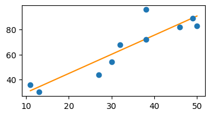

```python
import matplotlib.pyplot as plt
x_ep = np.array([np.min(x), np.max(x)])
y_ep = beta[0] + beta[1] * x_ep
plt.figure(figsize=[4,2])
plt.scatter(x, y, zorder=2)
plt.plot(x_ep, y_ep, color='darkorange', zorder=1)
plt.show()
```

# Submission Instructions

1. The cell below will generate an HTML render of your notebook within the same Google Drive folder in which you stored this notebook. Adjust the path for your notebook in the cell below as needed.
2. Restart your notebook and run it from start to finish.
3. If the notebook executes without error, download the HTML export of the notebook and then upload it to Canvas. Make sure to carefully review the contents of the HTML export to ensure that everything is displayed correctly.
4. Click on "Share" in the upper-right corner of this notebook. Then select "Anyone with the link" from dropdown. Click "Copy Link" and paste the copied link as a comment in your submission on Canvas.

```python
%%capture
import time
time.sleep(30)
!jupyter nbconvert --to html /content/drive/MyDrive/MATH_509/Lab_03_dcarter8.ipynb
```